# Repaso práctico

Preparación y análisis descriptivo de una encuesta

Jesús Martín Godoy

godoy@ugr.es

Departamento de Sociología  
Universidad de Granada

Nadia Adelshina

anadia@ugr.es

Departamento de Ciencia Política y de la Administración  
Universidad de Granada

20 de noviembre de 2026

## La porra de los dieces

En la encuesta de **40dB.**, cada persona puntuó de **0 a 10** la probabilidad de votar a cada partido que se le mostró.

**Persona 176**

| Partido | Puntos |
| --- | --- |
| PSOE | 0 |
| PP | 8 |
| Vox | 8 |
| Frente Amplio | 0 |
| Podemos | **10** |
| Se Acabó la Fiesta | **10** |

Esta persona dio **dos dieces**.

**Tu apuesta**

En las 2.000 entrevistas reales, **¿cuántos dieces dio la persona que más dieces puso?**

## Del CSV al data frame

Coloca el CSV de la práctica en la carpeta `datos` de tu proyecto de RStudio.

```r
library(tidyverse)
datos <- read_csv("datos/tracking_40db_dia07_p4.csv")
glimpse(datos)
```

- `library(tidyverse)` carga los paquetes que usaremos en esta sesión.
- `read_csv()` lee el archivo de la ruta entre comillas. Con `<-` guardamos la tabla en el objeto `datos`.
- `glimpse(datos)` muestra las dimensiones de la tabla, las columnas y sus tipos.

> *Nota.* Si quieres explorar la encuesta completa, descarga los microdatos originales en CSV. Ese archivo tiene **una fila por entrevista**.

## Los datos de la porra en formato SPSS

Descarga el archivo SAV de la práctica y guárdalo en la carpeta `datos`. Para abrirlo usamos `read_sav()`, del paquete **haven**.

```r
library(haven)
datos <- read_sav("datos/tracking_40db_dia07_p4.sav")
glimpse(datos)
```

Obtendrás las mismas **tres columnas** que con el CSV de la porra.

## Qué aparece al ejecutar el código

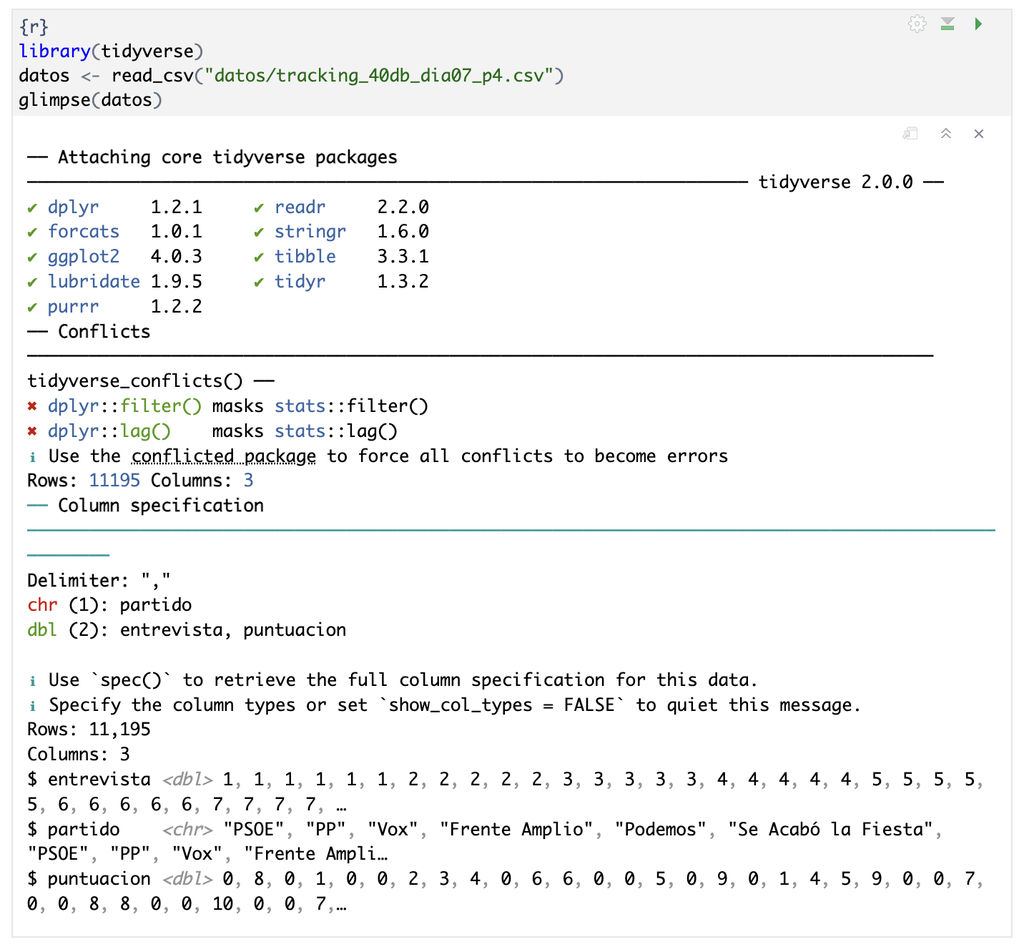

**Al cargar `tidyverse`.** R muestra qué paquetes se han cargado.

**¿Qué significa *Conflicts*?** R carga `stats` por defecto al iniciar la sesión. Al cargar `tidyverse`, `dplyr` queda por delante de `stats` en el orden de búsqueda. Ambos tienen una función llamada `filter()`, así que R encuentra primero la de `dplyr`.

Para elegir una versión, podemos escribir `dplyr::filter()` o `stats::filter()`. En la porra usaremos la de **dplyr** para seleccionar filas.

**Al leer el CSV.** R indica que encontró una columna de texto (`chr`) y dos numéricas (`dbl`).

**Al ejecutar `glimpse()`.** R muestra el tamaño de la tabla y una vista rápida de sus columnas. En la captura, `entrevista` corresponde a la columna `persona` del archivo de la práctica.

## Qué muestra `glimpse(datos)`

```
Rows: 11,195
Columns: 3
$ persona    <dbl> 1, 1, 1, 1, 1, 1, 2, 2, 2, 2, 2, 3, 3, 3, 3, 3, 4, 4, 4, 4,…
$ partido    <chr> "PSOE", "PP", "Vox", "Frente Amplio", "Podemos", "Se Acabó …
$ puntuacion <dbl> 0, 8, 0, 1, 0, 0, 2, 3, 4, 0, 6, 6, 0, 0, 5, 0, 9, 0, 1, 4,…
```

**¿Por qué se repite el número de la columna `persona`?**

## Nos quedamos con los dieces

La tabla `datos` recoge las puntuaciones de **las 2.000 personas encuestadas** a todos los partidos que se mostraron en sus entrevistas. **Cada fila contiene la puntuación de una persona a un partido.**

Aplicamos el filtro a **toda la tabla** y excluimos las filas con puntuaciones distintas de **10**. Cada fila que queda indica **quién dio un 10 y a qué partido**. **En el siguiente paso** contaremos cuántos dieces dio cada persona para averiguar quiénes dieron más.

```r
dieces <- datos |>
  filter(puntuacion == 10)
```

- `|>` pasa la tabla `datos` al siguiente paso.
- `filter()` conserva las filas donde `puntuacion == 10`. Leemos `==` como «es igual a».
- `<-` guarda la tabla resultante en el objeto `dieces`.

**Ya tenemos los dieces. ¿Cómo contamos cuántos dio cada persona?**

## El resultado del filtro

[figure not shown]

Persona 176 · dos dieces

Persona 204 · dos dieces

## Contamos los dieces de cada persona

En `dieces`, **cada fila recoge un 10 que una persona dio a un partido**. Si esa persona dio un 10 a varios partidos, aparece en varias filas.

Con **`group_by(persona)`**, juntamos las filas que tienen el mismo número en la columna `persona`. Como cada fila contiene un 10, **el número de filas de esa persona nos dice cuántos dieces dio**.

- **`n()`** cuenta cuántas filas hay en el grupo. Si una persona tiene dos filas, `n()` da 2.
- **`summarise()`** crea una tabla de resumen con **una fila por grupo**.

```r
recuento_dieces <- dieces |>
  group_by(persona) |>
  summarise(n_dieces = n())
```

En **`n_dieces = n()`**, a la **izquierda del `=`** ponemos el nombre de la nueva columna. A la **derecha** va el cálculo que guardamos en ella.

`<-` guarda la tabla de resumen en **`recuento_dieces`**. Por ejemplo, la persona **176** queda en una sola fila con `n_dieces` igual a **2**.

**¿Cómo vemos quiénes dieron más dieces?**

## El resultado del recuento

[figure not shown]

## ¿Quiénes dieron más dieces?

Queremos poner **arriba** a las personas que dieron más dieces.

```r
recuento_dieces |>
  arrange(desc(n_dieces))
```

- `arrange()` ordena las filas por la columna que le indicamos.
- `desc(n_dieces)` pone los recuentos más altos primero.

**¿Cuál fue el máximo? ¿Cuántas personas llegaron a él?**

| `persona` | `n_dieces` |
| --- | --- |
| 225 | **3** |
| 558 | **3** |
| 703 | **3** |
| 767 | **3** |
| 1451 | **3** |
| 1992 | **3** |

**Tres dieces. Seis personas llegaron a ese máximo.**

> *Nota.* La consola muestra el resultado ordenado. Para abrirlo desde **Environment**, añade `recuento_ordenado <-` delante de `recuento_dieces |>`. Luego haz clic en `recuento_ordenado`.

## Una alternativa para resolver la porra

Queremos obtener una tabla con **todas las personas que dieron más dieces**. Primero pedimos a R que averigüe cuál fue el recuento más alto.

```r
maximo_dieces <- max(recuento_dieces$n_dieces)

personas_con_mas_dieces <- recuento_dieces |>
  filter(n_dieces == maximo_dieces)
```

**Cuatro filas de `recuento_dieces`**

| `persona` | `n_dieces` |
| --- | --- |
| 7 | 1 |
| 176 | 2 |
| 225 | 3 |
| 558 | 3 |

**1. ¿Qué números queremos mirar?**

Con `recuento_dieces$n_dieces` sacamos los recuentos de las personas que aparecen en esa tabla. A la izquierda de `$` ponemos la tabla y a la derecha, la columna.

**2. ¿Cuál es el número más alto?**

`max()` devuelve el mayor de los números que le damos entre paréntesis. Con los cuatro del ejemplo, `max(c(1, 2, 3, 3))` da **3**. En el código, le damos la columna entera y guardamos el resultado en `maximo_dieces`.

**3. ¿Quiénes llegaron a ese número?**

`filter()` conserva las filas que igualan el máximo (`==`). Con `<-` guardamos la tabla. En **Environment**, haz clic en `personas_con_mas_dieces`.

> *Para elegir entre varios valores*, usaríamos `n_dieces %in% c(2, 3)`. Así se quedan quienes dieron **2 o 3 dieces**.

## Las personas que llegaron al máximo

[figure not shown]

## Las puntuaciones de las seis personas

Estas seis personas puntuaron a los mismos seis partidos. Destacamos en azul las puntuaciones de **10**.

| Persona | PSOE | PP | Vox | Frente Amplio | Podemos | Se Acabó la Fiesta |
| --- | --- | --- | --- | --- | --- | --- |
| 225 | **10** | 0 | 0 | **10** | **10** | 0 |
| 558 | **10** | 0 | 0 | **10** | **10** | 0 |
| 703 | **10** | 0 | 0 | **10** | **10** | 0 |
| 767 | **10** | 0 | 0 | **10** | **10** | 0 |
| 1451 | 0 | **10** | **10** | 6 | 6 | **10** |
| 1992 | **10** | 0 | 0 | **10** | **10** | 0 |

## ¿Fue habitual dar más de un diez?

En `recuento_dieces` tenemos **una fila por cada persona que dio al menos un 10**.

Vamos a crear una tabla de resumen llamada **`frecuencia_dieces`**. Cada fila dirá cuántas personas dieron **uno, dos o tres dieces**.

**¿Por qué columna agrupamos para obtener esa tabla?**

```r
frecuencia_dieces <- recuento_dieces |>
  group_by(n_dieces) |>
  summarise(n_personas = n())

frecuencia_dieces
```

Agrupamos a las personas que dieron **el mismo número de dieces**. `n()` cuenta cuántas personas hay en cada grupo.

| Dieces por persona | Número de personas |
| --- | --- |
| 1 | 788 |
| 2 | 43 |
| 3 | 6 |

De las **837 personas** que dieron algún 10, **49 dieron más de uno**.

**2.000 − 837 = 1.163** personas no dieron ningún 10.

## Repasamos `mutate()` al calcular porcentajes

Vamos a usar **`mutate()` para añadir una columna de porcentajes** a la tabla `frecuencia_dieces`.

49 personas dieron más de un diez. Antes de calcular el porcentaje, **¿49 de cuántas?**

**De toda la muestra**

49 de 2.000 personas son **el 2,45 %**.

**De quienes dieron al menos un 10**

49 de 837 personas son **el 5,85 %**.

**Añadimos el porcentaje sobre las 2.000 personas a la tabla de frecuencias**

```r
frecuencia_final <- frecuencia_dieces |>
  mutate(porcentaje_muestra = 100 * n_personas / 2000)
```

`mutate()` crea la columna `porcentaje_muestra` y hace el cálculo en cada fila.

## La tabla `frecuencia_final` en RStudio

[figure not shown]

## Guardamos la tabla en distintos formatos

`frecuencia_final` es la tabla que queremos guardar. El nombre entre comillas indica qué archivo se crea en la carpeta del proyecto.

**CSV**

```r
write_csv(frecuencia_final, "frecuencia_dieces.csv")
```

**Excel (.xlsx)**

```r
library(writexl)
write_xlsx(frecuencia_final, "frecuencia_dieces.xlsx")
```

Si te falta el paquete, instálalo una vez con `install.packages("writexl")`.

**SPSS (.sav)**

```r
library(haven)
write_sav(frecuencia_final, "frecuencia_dieces.sav")
```

**Para abrirlo en otra sesión de R (.rds)**

```r
saveRDS(frecuencia_final, "frecuencia_dieces.rds")
```

Puedes recuperar la tabla con `readRDS()`.

## Filas, columnas y nombres

Seguimos con la tabla `datos` de la porra. Estas tres instrucciones parten de la misma tabla.

```r
datos |> filter(puntuacion == 10)

datos |> select(partido, puntuacion)

datos |> rename(nota = puntuacion)
```

- **`filter()` elige filas.** Conserva las puntuaciones de 10.
- **`select()` elige columnas.** Conserva el partido y su puntuación.
- **`rename()` cambia nombres.** Con `nota = puntuacion`, `nota` es el nombre nuevo.

**Salida de R · primeras tres filas**

**Después de `filter()`**

```
# A tibble: 892 × 3
  persona partido puntuacion
    <dbl> <chr>        <dbl>
1       7 PSOE            10
2       8 PP              10
3       9 Vox             10
# ℹ 889 more rows
```

**Después de `select()`**

```
# A tibble: 11,195 × 2
  partido puntuacion
  <chr>        <dbl>
1 PSOE             0
2 PP               8
3 Vox              0
# ℹ 11,192 more rows
```

**Después de `rename()`**

```
# A tibble: 11,195 × 3
  persona partido  nota
    <dbl> <chr>   <dbl>
1       1 PSOE        0
2       1 PP          8
3       1 Vox         0
# ℹ 11,192 more rows
```

## Por qué convertimos el 99 en `NA`

El **99** significa «No lo sé». Como está guardado como número, R lo incluye si calculamos la media directamente.

```r
mean(datos$puntuacion)

datos_para_media <- datos |>
  mutate(puntuacion = na_if(puntuacion, 99))

mean(datos_para_media$puntuacion, na.rm = TRUE)
```

- **`na_if(puntuacion, 99)`** cambia cada 99 por `NA` en `datos_para_media`.
- **`na.rm = TRUE`** le dice a `mean()` que omita los `NA` al calcular la media.

**Salida de R**

**Media contando los 99 como números**

```
[1] 6.249397
```

**Media de las puntuaciones de 0 a 10**

```
[1] 3.008228
```

> *Nota.* Si quieres obtener una tabla con las puntuaciones disponibles, aplica `drop_na(puntuacion)` a `datos_para_media`.

## De las puntuaciones a los tramos

`mutate()` crea la columna `tramo`. **`case_when()`** revisa las condiciones de arriba abajo y asigna la categoría de la primera que se cumple.

```r
datos_por_tramos <- datos |>
  mutate(tramo = case_when(
    puntuacion == 99 ~ "No lo sé",
    puntuacion <= 4  ~ "0–4",
    puntuacion <= 7  ~ "5–7",
    puntuacion <= 10 ~ "8–10"
  ))

datos_por_tramos
```

**Salida de R · primeras tres filas**

```
# A tibble: 11,195 × 4
  persona partido puntuacion tramo
    <dbl> <chr>        <dbl> <chr>
1       1 PSOE             0 0–4
2       1 PP               8 8–10
3       1 Vox              0 0–4
# ℹ 11,192 more rows
```

**¿En qué tramo quedan un 7, un 8 y un 99?**

> *Nota.* Un factor ordenado permite mantener el orden de los tramos **0–4, 5–7 y 8–10** al presentarlos en una tabla o un gráfico.

## Para profundizar

- **Para consultar una función.** La ficha de Posit reúne ejemplos breves de `filter()`, `select()`, `mutate()`, `group_by()` y `summarise()`. [Guía rápida de transformación con dplyr](https://opensource.posit.co/resources/cheatsheets/data-transformation/data-transformation_es.pdf)
- **Para practicar por tu cuenta.** El capítulo de transformación de *R para Ciencia de Datos* explica estas funciones con ejemplos y ejercicios. [Transformación de datos](https://es.r4ds.hadley.nz/05-transform.html)
- **Para el próximo taller.** Si quieres iniciarte en la visualización con R, te invito a repasar el capítulo [Visualización de datos](https://es.r4ds.hadley.nz/03-visualize.html).

## Qué hemos hecho y qué viene después

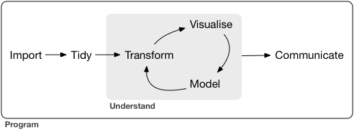

**Lo que hicimos con la porra**

Importamos el CSV, comprobamos qué representaba cada fila, filtramos y resumimos los datos. Explicamos el resultado y vimos cómo guardar las tablas.

**La semana que viene · Visualización de datos**

Aprenderemos a convertir tablas en gráficos para explorar y comunicar resultados. La modelización queda como otra etapa pendiente.

Flujo de trabajo de [*R for Data Science*](https://r4ds.had.co.nz/introduction.html), de Hadley Wickham y Garrett Grolemund.

## ¿Dudas?

## ¡Gracias!

Nos vemos la semana que viene en el taller de **visualización de datos**.